# BaCoN - Tutorial

## 3.2 Compute BaCoN matrix:

`BaCoN` may behave unexpectedly if the input correlation matrix is formatted in an unexpected way. To ensure stable and reliable results, please ensure that the input matrix…

1. is a correlation matrix or composed of comparable values scaling between -1 and 1. BaCoN is currently not designed to work e.g. on negative logarithmic p-values or other association indices.
2. does not contain NAs. This should not cause problems in cases of single NA values, but entire NA rows or columns should be removed from the matrix.
3. should not have duplicated row- or column names. Each gene should be represented in one row and/or column only.

```r
prediction_matrices[,,"BaCoN"] <- BaCoN(prediction_matrices[,,"PCC"])
```

## 4. Cholesky whitening + PCC + BaCoN

`BaCoN` alone creates a buffering prediction matrix that can be used, but we observed that combining `BaCoN` with pre-hoc covariance normalization methods further increases the quality of predictions (less false positives, higher number of paralogs). Next, we combine `BaCoN` with the pre-hoc covariance normalization method Cholesky whitening, as proposed in our manuscript.

We use the `whitening` package and its `whiten` function.

```r
if (F) {install.packages(whitening)}
library(whitening)
```

We whiten both input matrices independently. It is important that the cell lines of both objects are identical and in the second dimension (columns) of the object. Therefore, we transpose the objects before and retranspose them after the whitening.

```r
whitened_ge_subset <- t(whiten(t(ge_subset), method = "Cholesky"))
whitened_chronos_subset <- t(whiten(t(chronos_subset), method = "Cholesky"))

prediction_matrices[,,"Cholesky_PCC"] <- cor(
  whitened_ge_subset,
  whitened_chronos_subset,
  use = "pairwise.complete.obs")

prediction_matrices[,,"Cholesky_BaCoN"] <- BaCoN(prediction_matrices[,,"Cholesky_PCC"])
```

## 5. Collect top 1000 predictions:

```r
predictions <- data.table(data.frame(
  expression_gene = rep(rownames(prediction_matrices),
                        ncol(prediction_matrices)),
  chronos_gene = rep(colnames(prediction_matrices),
                     each = nrow(prediction_matrices)),
    PCC = as.vector(prediction_matrices[,,"PCC"]),
  BaCoN = as.vector(prediction_matrices[,,"BaCoN"]),
  Cholesky_PCC = as.vector(prediction_matrices[,,"Cholesky_PCC"]),
  Cholesky_BaCoN = as.vector(prediction_matrices[,,"Cholesky_BaCoN"])
  )
  )


predictions[order(BaCoN, PCC, decreasing = T), BaCoN_rank := .I]
predictions[order(Cholesky_BaCoN, PCC, decreasing = T), Cholesky_BaCoN_rank := .I]

predictions <- predictions[order(Cholesky_BaCoN_rank, decreasing = F)]

predictions[1:25, .(expression_gene, chronos_gene, PCC, Cholesky_BaCoN)]
```

```
#>     expression_gene chronos_gene          PCC Cholesky_BaCoN
#>              <char>       <char>        <num>          <num>
#>  1:         TIMM17B      TIMM17A  0.402796282      0.9993804
#>  2:          CHMP4A       CHMP4B  0.356270247      0.9993804
#>  3:          PABPC4       PABPC1  0.351385289      0.9993804
#>  4:           UBE2C        UBE2S  0.217317198      0.9993804
#>  5:            DSTN         CFL1  0.503833765      0.9990706
#>  6:           SARAF       PPP2CA  0.285569734      0.9990706
#>  7:           ACTG1         ACTB  0.203234554      0.9941140
#>  8:            RPS2        PDCD2  0.230229090      0.9938042
#>  9:          CHCHD2        MSTO1  0.153289129      0.9925651
#> 10:           DDX17         DDX5  0.242464728      0.9913259
#> 11:           CCT6A        MSTO1  0.160806827      0.9903965
#> 12:         KHDRBS1         MFN2 -0.056669189      0.9897770
#> 13:          EIF4A3        IPO11  0.161218525      0.9894672
#> 14:            TUBB       TUBB4B  0.375054473      0.9888476
#> 15:          DDX39A       DDX39B  0.324062472      0.9885378
#> 16:          MRPS21       MRPS21  0.023700158      0.9845105
#> 17:         ZBTB8OS        DHX36  0.076016285      0.9835812
#> 18:            RAC1        RBBP6  0.011465075      0.9820322
#> 19:          CHMP2A        CHMP3  0.330602239      0.9792441
#> 20:            ETFB         ADSL  0.069429072      0.9792441
#> 21:            SBDS       ZNF407  0.047587250      0.9767658
#> 22:           NOP10        PSMG1  0.029436062      0.9752169
#> 23:         ATP5F1E        RPP14  0.066836447      0.9745973
#> 24:            SLBP       SERBP1  0.006998759      0.9742875
#> 25:          TXNL4A        VPS4A  0.343127157      0.9736679
#>     expression_gene chronos_gene          PCC Cholesky_BaCoN
```

## 6. Show score distribution and predictions

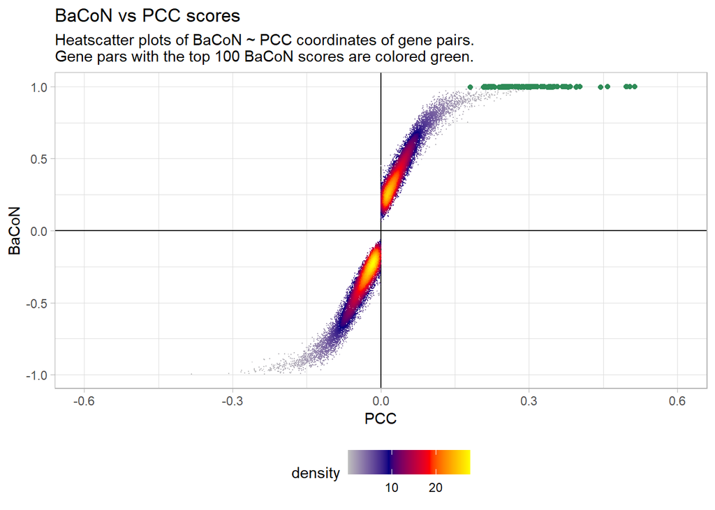

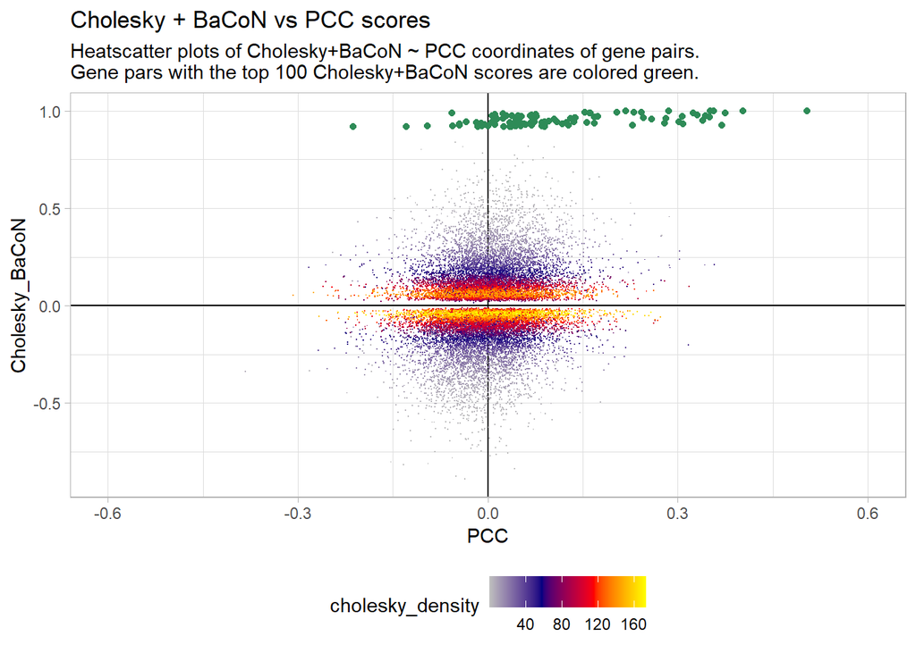

# Summary

```r
str(ge_complete)
```

```
#>  num [1:1673, 1:19193] 4.33 4.57 3.15 4.24 4.03 ...
#>  - attr(*, "dimnames")=List of 2
#>   ..$ : chr [1:1673] "ACH-001113" "ACH-001289" "ACH-001339" "ACH-001979" ...
#>   ..$ : chr [1:19193] "TSPAN6" "TNMD" "DPM1" "SCYL3" ...
```

```r
str(chronos_complete)
```

```
#>  num [1:1178, 1:17916] -0.122 -0.0165 -0.1848 -0.0719 -0.0192 ...
#>  - attr(*, "dimnames")=List of 2
#>   ..$ : chr [1:1178] "ACH-000001" "ACH-000004" "ACH-000005" "ACH-000007" ...
#>   ..$ : chr [1:17916] "A1BG" "A1CF" "A2M" "A2ML1" ...
```

```r
str(ge_subset)
```

```
#>  num [1:1103, 1:1460] 7.11 7.15 6.54 6.09 6.53 ...
#>  - attr(*, "dimnames")=List of 2
#>   ..$ : chr [1:1103] "ACH-001289" "ACH-001538" "ACH-000242" "ACH-000233" ...
#>   ..$ : chr [1:1460] "DPM1" "LASP1" "M6PR" "ARF5" ...
```

```r
str(chronos_subset)
```

```
#>  num [1:1103, 1:1768] -1.24 -0.869 -0.83 -0.845 -1.109 ...
#>  - attr(*, "dimnames")=List of 2
#>   ..$ : chr [1:1103] "ACH-001289" "ACH-001538" "ACH-000242" "ACH-000233" ...
#>   ..$ : chr [1:1768] "AAMP" "AARS1" "AARS2" "AATF" ...
```

```r
str(prediction_matrices)
```

```
#>  num [1:1460, 1:1768, 1:4] 0.07661 0.10543 0.00668 0.08391 0.01036 ...
#>  - attr(*, "dimnames")=List of 3
#>   ..$ : chr [1:1460] "DPM1" "LASP1" "M6PR" "ARF5" ...
#>   ..$ : chr [1:1768] "AAMP" "AARS1" "AARS2" "AATF" ...
#>   ..$ : chr [1:4] "PCC" "BaCoN" "Cholesky_PCC" "Cholesky_BaCoN"
```

```r
str(predictions)
```

```
#> Classes 'data.table' and 'data.frame':   2581280 obs. of  8 variables:
#>  $ expression_gene    : chr  "TIMM17B" "CHMP4A" "PABPC4" "UBE2C" ...
#>  $ chronos_gene       : chr  "TIMM17A" "CHMP4B" "PABPC1" "UBE2S" ...
#>  $ PCC                : num  0.403 0.356 0.351 0.217 0.504 ...
#>  $ BaCoN              : num  0.999 0.999 0.999 0.999 0.999 ...
#>  $ Cholesky_PCC       : num  0.153 0.153 0.164 0.178 0.142 ...
#>  $ Cholesky_BaCoN     : num  0.999 0.999 0.999 0.999 0.999 ...
#>  $ BaCoN_rank         : int  1 17 5 26 15 11 2062 90 1163 105 ...
#>  $ Cholesky_BaCoN_rank: int  1 2 3 4 5 6 7 8 9 10 ...
#>  - attr(*, ".internal.selfref")=<externalptr>
```